# MAVE QC Report

MAVEQC-v0.2.2

2023-08-31 15:54:40

## 1. Introduction

MAVEQC is a flexible R-package that provides QC analysis of Saturation Genome Editing (SGE) experimental data. Available under GPL 3.0 from https://github.com/wtsi-hgi/MAVEQC

## 2. Screen QC

Displays QC plots and statistics for all samples for QC.

### 2.1. Sample Sheet

| sample_name | library_independent_count | library_dependent_count | valiant_meta | vep_anno | adapt5 | adapt3 | per_r1_adaptor | per_r2_adaptor | library_name | library_type |
| --- | --- | --- | --- | --- | --- | --- | --- | --- | --- | --- |
| hgkd2_d4_r1 | Rep1_HGKD2_Day4.query_counts.tsv.gz | Rep1_HGKD2_Day4.lib_counts.tsv.gz | meta.csv.gz | meta_consequences.tsv.gz | AATGATACGGCGACCACCGAGGATTTAGTGGTCCCTGAGAGTGGCTCGTATGCCGTCTTCTGCTTG | GGATTTAGTGGTCCCTGAGAGTGGCTCGTATGCCGTCTTCTGCTTG | 0.328262 | NA | KMT2D_exon53 | screen |
| hgkd2_d7_r1 | Rep1_HGKD2_Day7.query_counts.tsv.gz | Rep1_HGKD2_Day7.lib_counts.tsv.gz | meta.csv.gz | meta_consequences.tsv.gz | AATGATACGGCGACCACCGAGGATTTAGTGGTCCCTGAGAGTGGCTCGTATGCCGTCTTCTGCTTG | GGATTTAGTGGTCCCTGAGAGTGGCTCGTATGCCGTCTTCTGCTTG | 0.327821 | NA | KMT2D_exon53 | screen |
| hgkd2_d21_r1 | Rep1_HGKD2_Day21.query_counts.tsv.gz | Rep1_HGKD2_Day21.lib_counts.tsv.gz | meta.csv.gz | meta_consequences.tsv.gz | AATGATACGGCGACCACCGAGGATTTAGTGGTCCCTGAGAGTGGCTCGTATGCCGTCTTCTGCTTG | GGATTTAGTGGTCCCTGAGAGTGGCTCGTATGCCGTCTTCTGCTTG | 0.325619 | NA | KMT2D_exon53 | screen |
| hgkd2_d4_r2 | Rep2_HGKD2_Day4.query_counts.tsv.gz | Rep2_HGKD2_Day4.lib_counts.tsv.gz | meta.csv.gz | meta_consequences.tsv.gz | AATGATACGGCGACCACCGAGGATTTAGTGGTCCCTGAGAGTGGCTCGTATGCCGTCTTCTGCTTG | GGATTTAGTGGTCCCTGAGAGTGGCTCGTATGCCGTCTTCTGCTTG | 0.327883 | NA | KMT2D_exon53 | screen |
| hgkd2_d7_r2 | Rep2_HGKD2_Day7.query_counts.tsv.gz | Rep2_HGKD2_Day7.lib_counts.tsv.gz | meta.csv.gz | meta_consequences.tsv.gz | AATGATACGGCGACCACCGAGGATTTAGTGGTCCCTGAGAGTGGCTCGTATGCCGTCTTCTGCTTG | GGATTTAGTGGTCCCTGAGAGTGGCTCGTATGCCGTCTTCTGCTTG | 0.327513 | NA | KMT2D_exon53 | screen |
| hgkd2_d21_r2 | Rep2_HGKD2_Day21.query_counts.tsv.gz | Rep2_HGKD2_Day21.lib_counts.tsv.gz | meta.csv.gz | meta_consequences.tsv.gz | AATGATACGGCGACCACCGAGGATTTAGTGGTCCCTGAGAGTGGCTCGTATGCCGTCTTCTGCTTG | GGATTTAGTGGTCCCTGAGAGTGGCTCGTATGCCGTCTTCTGCTTG | 0.328318 | NA | KMT2D_exon53 | screen |
| hgkd2_d4_r3 | Rep3_HGKD2_Day4.query_counts.tsv.gz | Rep3_HGKD2_Day4.lib_counts.tsv.gz | meta.csv.gz | meta_consequences.tsv.gz | AATGATACGGCGACCACCGAGGATTTAGTGGTCCCTGAGAGTGGCTCGTATGCCGTCTTCTGCTTG | GGATTTAGTGGTCCCTGAGAGTGGCTCGTATGCCGTCTTCTGCTTG | 0.32836 | NA | KMT2D_exon53 | screen |
| hgkd2_d7_r3 | Rep3_HGKD2_Day7.query_counts.tsv.gz | Rep3_HGKD2_Day7.lib_counts.tsv.gz | meta.csv.gz | meta_consequences.tsv.gz | AATGATACGGCGACCACCGAGGATTTAGTGGTCCCTGAGAGTGGCTCGTATGCCGTCTTCTGCTTG | GGATTTAGTGGTCCCTGAGAGTGGCTCGTATGCCGTCTTCTGCTTG | 0.328552 | NA | KMT2D_exon53 | screen |
| hgkd2_d21_r3 | Rep3_HGKD2_Day21.query_counts.tsv.gz | Rep3_HGKD2_Day21.lib_counts.tsv.gz | meta.csv.gz | meta_consequences.tsv.gz | AATGATACGGCGACCACCGAGGATTTAGTGGTCCCTGAGAGTGGCTCGTATGCCGTCTTCTGCTTG | GGATTTAGTGGTCCCTGAGAGTGGCTCGTATGCCGTCTTCTGCTTG | 0.326935 | NA | KMT2D_exon53 | screen |

### 2.2. Run Sample QC

#### 2.2.1. Read Length Distrubtion

Displays the percentage of reads for each sample, based on 50 nucleotide increments.

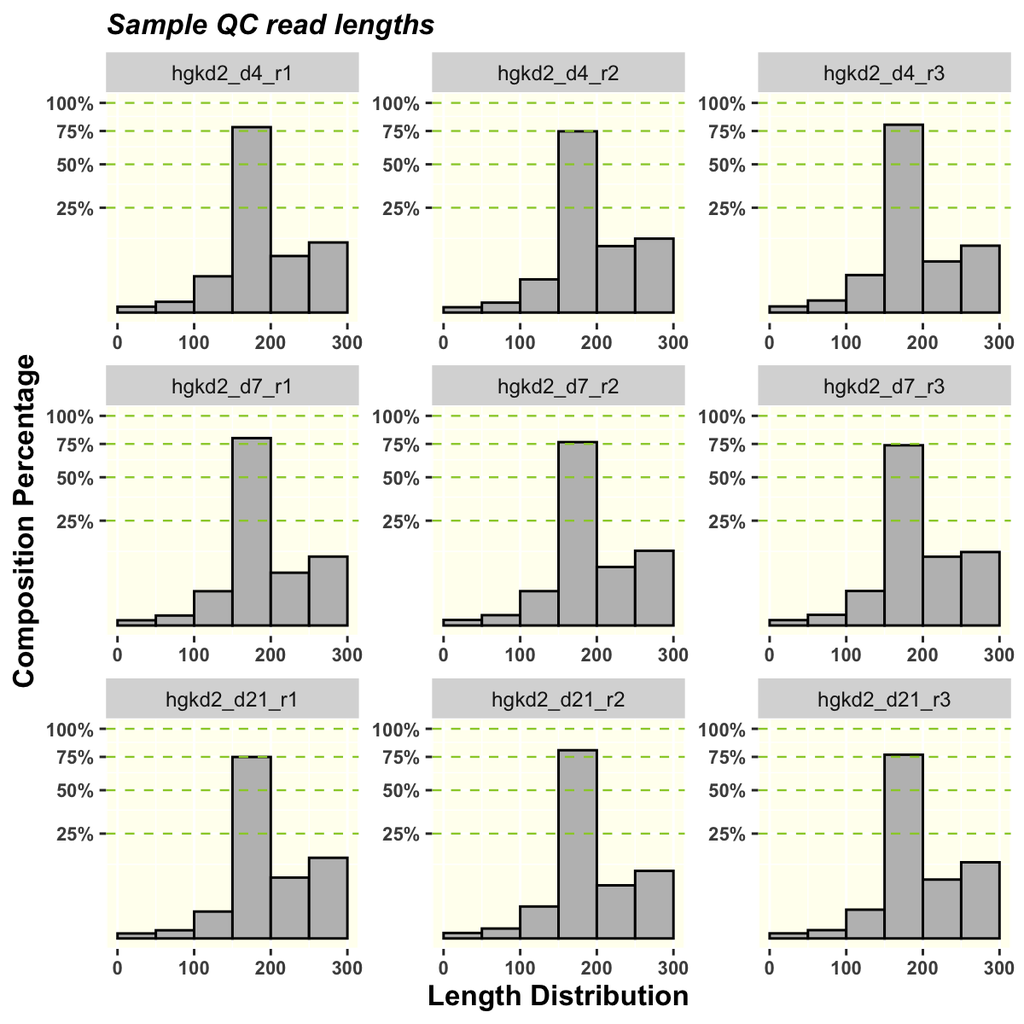

| Group | Sample | Total Reads | % 0 ~ 50 | % 50 ~ 100 | % 100 ~ 150 | % 150 ~ 200 | % 200 ~ 250 | % 250 ~ 300 | Pass Threshold | Pass |
| --- | --- | --- | --- | --- | --- | --- | --- | --- | --- | --- |
| KMT2D_exon53 | hgkd2_d4_r1 | 4997130 | 0.1 | 0.3 | 3 | 78.2 | 7.3 | 11.2 | 90 | False |
| KMT2D_exon53 | hgkd2_d4_r2 | 4769809 | 0.1 | 0.2 | 2.5 | 74.7 | 10 | 12.4 | 90 | False |
| KMT2D_exon53 | hgkd2_d4_r3 | 5475825 | 0.1 | 0.3 | 3.2 | 80.3 | 5.9 | 10.2 | 90 | False |
| KMT2D_exon53 | hgkd2_d7_r1 | 4961708 | 0.1 | 0.2 | 2.7 | 79.9 | 6.3 | 10.8 | 90 | False |
| KMT2D_exon53 | hgkd2_d7_r2 | 5161779 | 0.1 | 0.2 | 2.7 | 76.5 | 7.8 | 12.7 | 90 | False |
| KMT2D_exon53 | hgkd2_d7_r3 | 5751950 | 0.1 | 0.3 | 2.7 | 73.9 | 10.8 | 12.3 | 90 | False |
| KMT2D_exon53 | hgkd2_d21_r1 | 4895742 | 0.1 | 0.2 | 1.6 | 74.9 | 8.4 | 14.8 | 90 | False |
| KMT2D_exon53 | hgkd2_d21_r2 | 4662969 | 0.1 | 0.2 | 2.3 | 80.6 | 6.4 | 10.4 | 90 | False |
| KMT2D_exon53 | hgkd2_d21_r3 | 5157958 | 0.1 | 0.2 | 1.9 | 76.8 | 7.9 | 13.2 | 90 | False |

#### 2.2.2. Missing Variants

Missing variants in the library

| Group | Sample | Library Sequences | Missing Library Sequences | % Missing Library Sequences | Pass Threshold | Pass |
| --- | --- | --- | --- | --- | --- | --- |
| KMT2D_exon53 | hgkd2_d4_r1 | 923 | 3 | 0.3 | 1 | True |
| KMT2D_exon53 | hgkd2_d4_r2 | 923 | 3 | 0.3 | 1 | True |
| KMT2D_exon53 | hgkd2_d4_r3 | 923 | 3 | 0.3 | 1 | True |
| KMT2D_exon53 | hgkd2_d7_r1 | 923 | 3 | 0.3 | 1 | True |
| KMT2D_exon53 | hgkd2_d7_r2 | 923 | 3 | 0.3 | 1 | True |
| KMT2D_exon53 | hgkd2_d7_r3 | 923 | 3 | 0.3 | 1 | True |
| KMT2D_exon53 | hgkd2_d21_r1 | 923 | 3 | 0.3 | 1 | True |
| KMT2D_exon53 | hgkd2_d21_r2 | 923 | 3 | 0.3 | 1 | True |
| KMT2D_exon53 | hgkd2_d21_r3 | 923 | 3 | 0.3 | 1 | True |

| name | length | count | unique | sample |
| --- | --- | --- | --- | --- |
| ENST00000301067.12.ENSG00000167548.18_chr12:49022254_A>C_Gnomad2_rc | 292 | 0 | 0 | SGE_1096109892_Rep1_HGKD2_Day21 |
| ENST00000301067.12.ENSG00000167548.18_chr12:49022254_A>C_Gnomad2_rc | 292 | 0 | 0 | SGE_1096109892_Rep1_HGKD2_Day4 |
| ENST00000301067.12.ENSG00000167548.18_chr12:49022254_A>C_Gnomad2_rc | 292 | 0 | 0 | SGE_1096109892_Rep1_HGKD2_Day7 |
| ENST00000301067.12.ENSG00000167548.18_chr12:49022254_A>C_Gnomad2_rc | 292 | 0 | 0 | SGE_1096109892_Rep2_HGKD2_Day21 |
| ENST00000301067.12.ENSG00000167548.18_chr12:49022254_A>C_Gnomad2_rc | 292 | 0 | 0 | SGE_1096109892_Rep2_HGKD2_Day4 |
| ENST00000301067.12.ENSG00000167548.18_chr12:49022254_A>C_Gnomad2_rc | 292 | 0 | 0 | SGE_1096109892_Rep2_HGKD2_Day7 |
| ENST00000301067.12.ENSG00000167548.18_chr12:49022254_A>C_Gnomad2_rc | 292 | 0 | 0 | SGE_1096109892_Rep3_HGKD2_Day21 |
| ENST00000301067.12.ENSG00000167548.18_chr12:49022254_A>C_Gnomad2_rc | 292 | 0 | 0 | SGE_1096109892_Rep3_HGKD2_Day4 |
| ENST00000301067.12.ENSG00000167548.18_chr12:49022254_A>C_Gnomad2_rc | 292 | 0 | 0 | SGE_1096109892_Rep3_HGKD2_Day7 |
| ENST00000301067.12.ENSG00000167548.18_chr12:49022254_A>C_Gnomad3_chr12_rc | 292 | 0 | 0 | SGE_1096109892_Rep1_HGKD2_Day21 |

[output cut: 26 more lines]

#### 2.2.3. Total Reads

Displays the total number of reads per sample. Filtering based on 1-dimensional Kmean clustering that excludes unique sequences with low read counts.

- **Accepted reads**: Total read count for all unique sequences with sufficient reads.
- **Excluded reads**: Total read count for all unique sequences with insufficient reads.

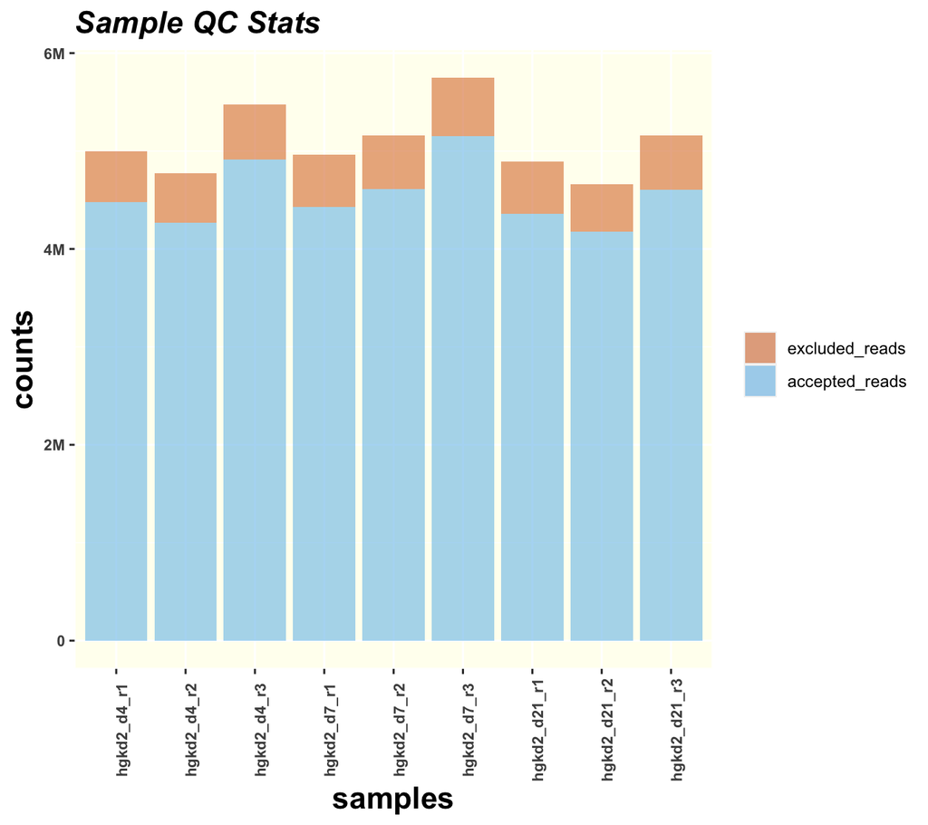

| Group | Sample | Accepted Reads | % Accepted Reads | Excluded Reads | % Excluded Reads | Total Reads | Pass Threshold | Pass |
| --- | --- | --- | --- | --- | --- | --- | --- | --- |
| KMT2D_exon53 | hgkd2_d4_r1 | 4481752 | 89.7 | 515378 | 10.3 | 4997130 | 1000000 | True |
| KMT2D_exon53 | hgkd2_d4_r2 | 4267854 | 89.5 | 501955 | 10.5 | 4769809 | 1000000 | True |
| KMT2D_exon53 | hgkd2_d4_r3 | 4913100 | 89.7 | 562725 | 10.3 | 5475825 | 1000000 | True |
| KMT2D_exon53 | hgkd2_d7_r1 | 4426321 | 89.2 | 535387 | 10.8 | 4961708 | 1000000 | True |
| KMT2D_exon53 | hgkd2_d7_r2 | 4610164 | 89.3 | 551615 | 10.7 | 5161779 | 1000000 | True |
| KMT2D_exon53 | hgkd2_d7_r3 | 5150725 | 89.5 | 601225 | 10.5 | 5751950 | 1000000 | True |
| KMT2D_exon53 | hgkd2_d21_r1 | 4360414 | 89.1 | 535328 | 10.9 | 4895742 | 1000000 | True |
| KMT2D_exon53 | hgkd2_d21_r2 | 4174344 | 89.5 | 488625 | 10.5 | 4662969 | 1000000 | True |
| KMT2D_exon53 | hgkd2_d21_r3 | 4603497 | 89.3 | 554461 | 10.7 | 5157958 | 1000000 | True |

#### 2.2.4. Accepted Reads

Displays the percentage of library reads vs non-library reads (ie. Reference, PAM and Unmapped) for Accepted Reads.

- **Library Reads**: Percentage reads mapping to template oligo sequences, including intended variants.
- **Reference Reads**: Percentage reads mapping to Reference.
- **PAM_Reads**: Percentage reads mapping to PAM/Protospacer Protection Edits (PPEs), without intended variant.
- **Unmapped Reads**: Percentage of Unmapped Reads.

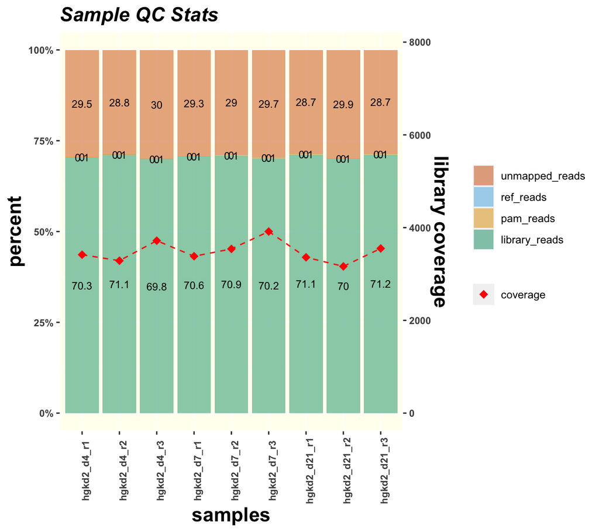

| Group | Sample | % Library Reads | % Reference Reads | % PAM Reads | % Unmapped Reads | Pass Threshold | Pass |
| --- | --- | --- | --- | --- | --- | --- | --- |
| KMT2D_exon53 | hgkd2_d4_r1 | 70.3 | 0 | 0.1 | 29.5 | 40 | True |
| KMT2D_exon53 | hgkd2_d4_r2 | 71.1 | 0 | 0.1 | 28.8 | 40 | True |
| KMT2D_exon53 | hgkd2_d4_r3 | 69.8 | 0 | 0.1 | 30 | 40 | True |
| KMT2D_exon53 | hgkd2_d7_r1 | 70.6 | 0 | 0.1 | 29.3 | 40 | True |
| KMT2D_exon53 | hgkd2_d7_r2 | 70.9 | 0 | 0.1 | 29 | 40 | True |
| KMT2D_exon53 | hgkd2_d7_r3 | 70.2 | 0 | 0.1 | 29.7 | 40 | True |
| KMT2D_exon53 | hgkd2_d21_r1 | 71.1 | 0 | 0.1 | 28.7 | 40 | True |
| KMT2D_exon53 | hgkd2_d21_r2 | 70 | 0 | 0.1 | 29.9 | 40 | True |
| KMT2D_exon53 | hgkd2_d21_r3 | 71.2 | 0 | 0.1 | 28.7 | 40 | True |

Defines the mean read count per template oligo sequence.

| Group | Sample | Total Library Reads | Total Library Sequences | Library Coverage | Median Coverage | Pass Threshold | Pass |
| --- | --- | --- | --- | --- | --- | --- | --- |
| KMT2D_exon53 | hgkd2_d4_r1 | 3152969 | 923 | 3416 | 2174.5 | 100 | True |
| KMT2D_exon53 | hgkd2_d4_r2 | 3033954 | 923 | 3287 | 2147 | 100 | True |
| KMT2D_exon53 | hgkd2_d4_r3 | 3431746 | 923 | 3718 | 2378 | 100 | True |
| KMT2D_exon53 | hgkd2_d7_r1 | 3123397 | 923 | 3383 | 2162 | 100 | True |
| KMT2D_exon53 | hgkd2_d7_r2 | 3268568 | 923 | 3541 | 2297 | 100 | True |
| KMT2D_exon53 | hgkd2_d7_r3 | 3614503 | 923 | 3916 | 2547 | 100 | True |
| KMT2D_exon53 | hgkd2_d21_r1 | 3101570 | 923 | 3360 | 2200.5 | 100 | True |
| KMT2D_exon53 | hgkd2_d21_r2 | 2921142 | 923 | 3164 | 2142.5 | 100 | True |
| KMT2D_exon53 | hgkd2_d21_r3 | 3278242 | 923 | 3551 | 2433 | 100 | True |

#### 2.2.5. Genomic Coverage

Distribution of variants across targeton region based on log2(count+1) values.

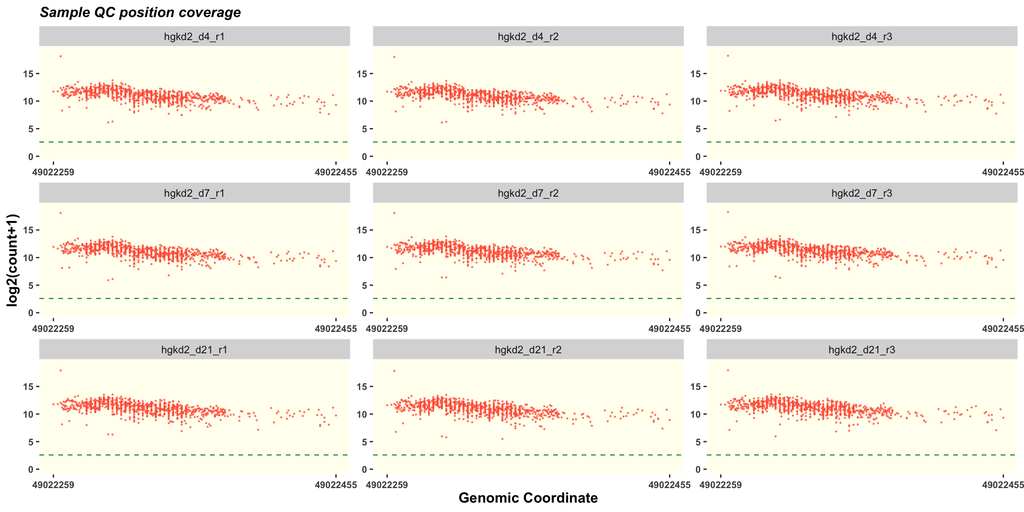

| Group | Sample | Chromosome | Strand | Genomic Start | Genomic End | % Low Abundance | Low Abundance cutoff | Pass Threshold | Pass |
| --- | --- | --- | --- | --- | --- | --- | --- | --- | --- |
| KMT2D_exon53 | hgkd2_d4_r1 | chr12 | - | 49022233 | 49022483 | 0 | 5 | 30 | True |
| KMT2D_exon53 | hgkd2_d4_r2 | chr12 | - | 49022233 | 49022483 | 0 | 5 | 30 | True |
| KMT2D_exon53 | hgkd2_d4_r3 | chr12 | - | 49022233 | 49022483 | 0 | 5 | 30 | True |
| KMT2D_exon53 | hgkd2_d7_r1 | chr12 | - | 49022233 | 49022483 | 0 | 5 | 30 | True |
| KMT2D_exon53 | hgkd2_d7_r2 | chr12 | - | 49022233 | 49022483 | 0 | 5 | 30 | True |
| KMT2D_exon53 | hgkd2_d7_r3 | chr12 | - | 49022233 | 49022483 | 0 | 5 | 30 | True |
| KMT2D_exon53 | hgkd2_d21_r1 | chr12 | - | 49022233 | 49022483 | 0 | 5 | 30 | True |
| KMT2D_exon53 | hgkd2_d21_r2 | chr12 | - | 49022233 | 49022483 | 0 | 5 | 30 | True |
| KMT2D_exon53 | hgkd2_d21_r3 | chr12 | - | 49022233 | 49022483 | 0 | 5 | 30 | True |

#### 2.2.6. Genomic Position Percentage

Displays distribution of “LOF” (loss-of-function) vs all “Other” variants across the targeton region, based on read percentages for reference timepoint. Requires concordant distribution of LOF and Other variants.

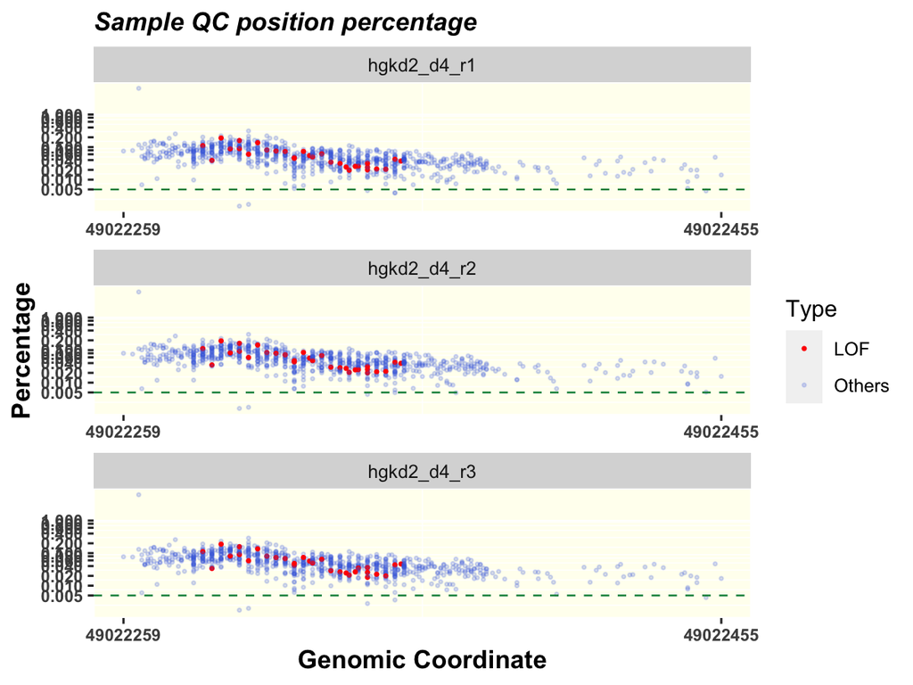

| Group | Sample | Chromosome | Strand | Genomic Start | Genomic End | % Low Abundance (LOF) | % Low Abundance (Others) | % Low Abundance (ALL) | % Low Abundance cutoff | Pass Threshold | Pass |
| --- | --- | --- | --- | --- | --- | --- | --- | --- | --- | --- | --- |
| KMT2D_exon53 | hgkd2_d4_r1 | chr12 | - | 49022233 | 49022483 | 0 | 0.7 | 0.7 | 0.005 | 30 | True |
| KMT2D_exon53 | hgkd2_d4_r2 | chr12 | - | 49022233 | 49022483 | 0 | 0.5 | 0.5 | 0.005 | 30 | True |
| KMT2D_exon53 | hgkd2_d4_r3 | chr12 | - | 49022233 | 49022483 | 0 | 0.5 | 0.5 | 0.005 | 30 | True |
| KMT2D_exon53 | hgkd2_d7_r1 | chr12 | - | 49022233 | 49022483 | 0 | 0.3 | 0.3 | 0.005 | 30 | True |
| KMT2D_exon53 | hgkd2_d7_r2 | chr12 | - | 49022233 | 49022483 | 0 | 0.7 | 0.7 | 0.005 | 30 | True |
| KMT2D_exon53 | hgkd2_d7_r3 | chr12 | - | 49022233 | 49022483 | 0 | 0.3 | 0.3 | 0.005 | 30 | True |
| KMT2D_exon53 | hgkd2_d21_r1 | chr12 | - | 49022233 | 49022483 | 0 | 0.7 | 0.7 | 0.005 | 30 | True |
| KMT2D_exon53 | hgkd2_d21_r2 | chr12 | - | 49022233 | 49022483 | 0 | 0.8 | 0.8 | 0.005 | 30 | True |
| KMT2D_exon53 | hgkd2_d21_r3 | chr12 | - | 49022233 | 49022483 | 0 | 0.7 | 0.7 | 0.005 | 30 | True |

### 2.3. Run Experiment QC

#### 2.3.1. Sample Correlations

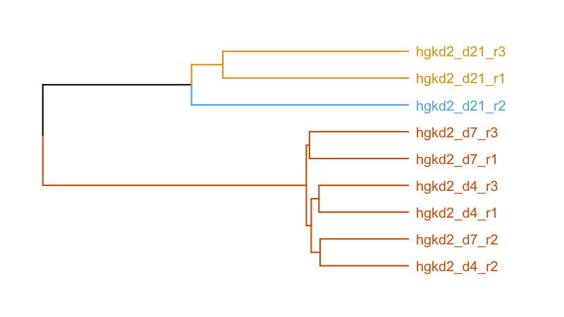

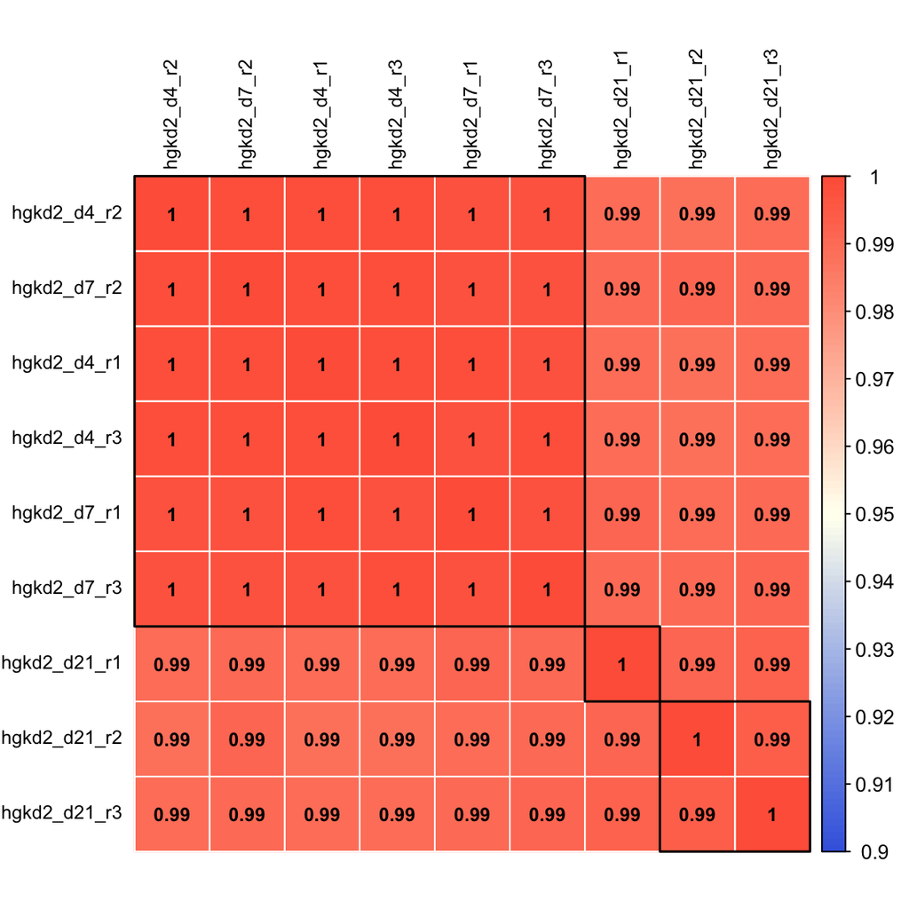

| Sample | Cluster | Replicate | Condition | hgkd2_d4_r1 | hgkd2_d7_r1 | hgkd2_d21_r1 | hgkd2_d4_r2 | hgkd2_d7_r2 | hgkd2_d21_r2 | hgkd2_d4_r3 | hgkd2_d7_r3 | hgkd2_d21_r3 | Pass |
| --- | --- | --- | --- | --- | --- | --- | --- | --- | --- | --- | --- | --- | --- |
| hgkd2_d4_r1 | 1 | R1 | D4 | 1 | 1 | 0.99 | 1 | 1 | 0.99 | 1 | 1 | 0.99 | False |
| hgkd2_d4_r2 | 1 | R2 | D4 | 1 | 1 | 0.99 | 1 | 1 | 0.99 | 1 | 1 | 0.99 | False |
| hgkd2_d4_r3 | 1 | R3 | D4 | 1 | 1 | 0.99 | 1 | 1 | 0.99 | 1 | 1 | 0.99 | False |
| hgkd2_d7_r1 | 1 | R1 | D7 | 1 | 1 | 0.99 | 1 | 1 | 0.99 | 1 | 1 | 0.99 | False |
| hgkd2_d7_r2 | 1 | R2 | D7 | 1 | 1 | 0.99 | 1 | 1 | 0.99 | 1 | 1 | 0.99 | False |
| hgkd2_d7_r3 | 1 | R3 | D7 | 1 | 1 | 0.99 | 1 | 1 | 0.99 | 1 | 1 | 0.99 | False |
| hgkd2_d21_r1 | 2 | R1 | D21 | 0.99 | 0.99 | 1 | 0.99 | 0.99 | 0.99 | 0.99 | 0.99 | 0.99 | False |
| hgkd2_d21_r2 | 3 | R2 | D21 | 0.99 | 0.99 | 0.99 | 0.99 | 0.99 | 1 | 0.99 | 0.99 | 0.99 | False |
| hgkd2_d21_r3 | 2 | R3 | D21 | 0.99 | 0.99 | 0.99 | 0.99 | 0.99 | 0.99 | 0.99 | 0.99 | 1 | False |

#### 2.3.2. Sample PCA

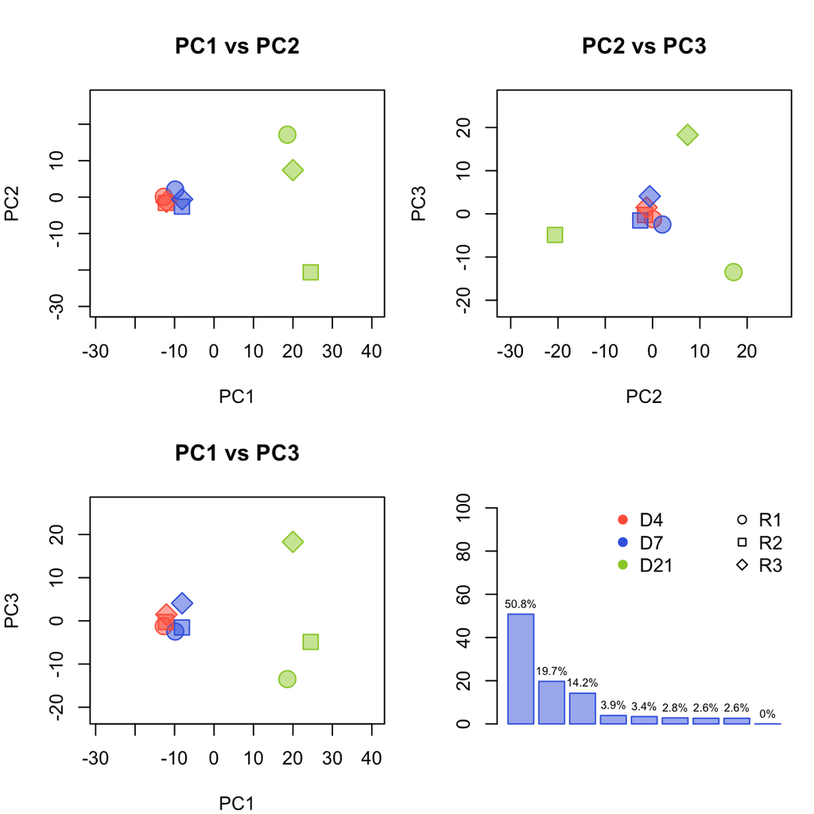

#### 2.3.3. Fold Change (by category)

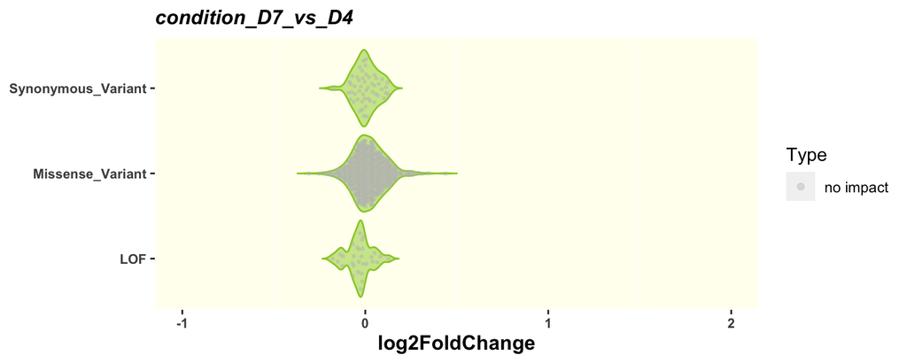

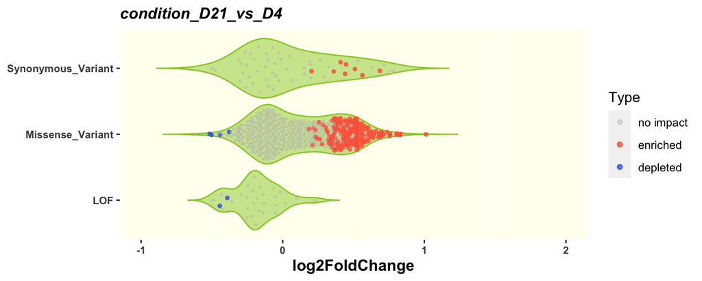

#### 2.3.4. Fold Change (by position)

**condition_D7_vs_D4**

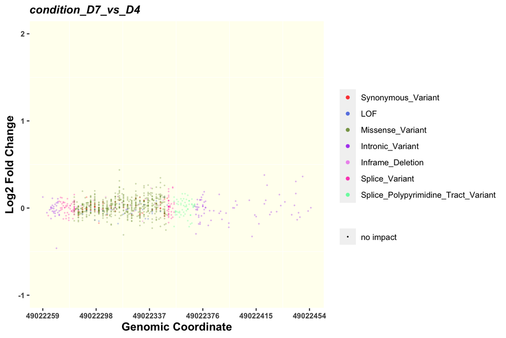

| oligo_name | consequence | position | adj_log2FoldChange | adj_fdr | stat |
| --- | --- | --- | --- | --- | --- |

**condition_D21_vs_D4**

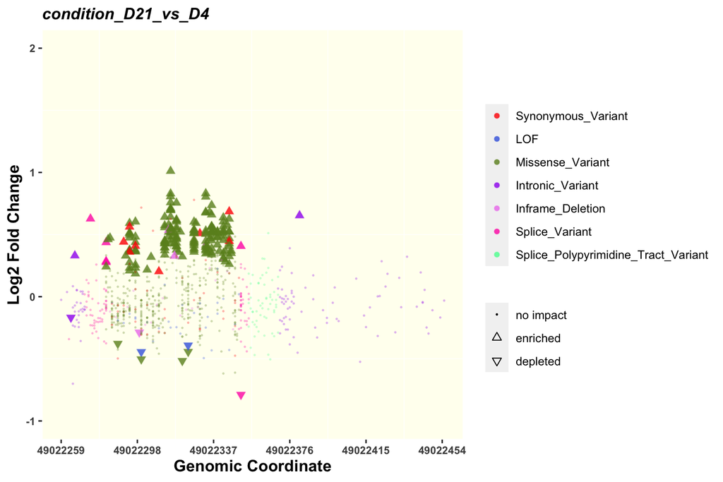

| oligo_name | consequence | position | adj_log2FoldChange | adj_fdr | stat |
| --- | --- | --- | --- | --- | --- |
| ENST00000301067.12.ENSG00000167548.18_chr12:49022318_49022320_TTC>GGT_aa_rc | Missense_Variant | 49022318 | 0.817385538517263 | 2.35406421815373e-23 | enriched |
| ENST00000301067.12.ENSG00000167548.18_chr12:49022336_49022338_CAT>GCT_aa_rc | Missense_Variant | 49022336 | 0.722172859139513 | 2.35406421815373e-23 | enriched |
| ENST00000301067.12.ENSG00000167548.18_chr12:49022294_49022296_AGT>GTC_aa_rc | Missense_Variant | 49022294 | 0.654034276329794 | 2.52671413192847e-20 | enriched |
| ENST00000301067.12.ENSG00000167548.18_chr12:49022297_49022299_TAA>CCG_aa_rc | Missense_Variant | 49022297 | 0.665433032701856 | 1.95015074644012e-19 | enriched |
| ENST00000301067.12.ENSG00000167548.18_chr12:49022294_49022296_AGT>GTG_aa_rc | Missense_Variant | 49022294 | 0.559751560648316 | 3.86606808536249e-18 | enriched |
| ENST00000301067.12.ENSG00000167548.18_chr12:49022315_A>C_snv_rc | Missense_Variant | 49022315 | 0.765139070767189 | 1.07672111642318e-15 | enriched |
| ENST00000301067.12.ENSG00000167548.18_chr12:49022294_49022296_AGT>GCT_snvre_rc | Missense_Variant | 49022294 | 0.574858313199641 | 1.53382412210353e-14 | enriched |
| ENST00000301067.12.ENSG00000167548.18_chr12:49022315_49022317_ATG>GCC_aa_rc | Missense_Variant | 49022315 | 0.760492165272052 | 1.35054606388571e-13 | enriched |
| ENST00000301067.12.ENSG00000167548.18_chr12:49022330_T>C_snv_rc | Synonymous_Variant | 49022330 | 0.571666816049056 | 2.9017576088087e-14 | enriched |
| ENST00000301067.12.ENSG00000167548.18_chr12:49022265_1del_rc | Intronic_Variant | 49022264 | -0.105501615729085 | 0.000609045376358913 | depleted |

[output cut: 172 more lines]

## 3. QC Results

Summarising the final results, below are the cutoffs using for PASS/FAIL

[output not shown]

### 3.1. Sample QC Results

| Group | Sample | Gini Coefficient | Total Reads | % Missing Variants | Accepted Reads | % Mapping Reads | % Reference Reads | % Library Reads | Library Coverage | % R1 Adatpor | % R2 Adaptor |
| --- | --- | --- | --- | --- | --- | --- | --- | --- | --- | --- | --- |
| KMT2D_exon53 | hgkd2_d4_r1 | 0.505 | True | True | True | True | True | True | True | 0.3283 | 0 |
| KMT2D_exon53 | hgkd2_d4_r2 | 0.499 | True | True | True | True | True | True | True | 0.3279 | 0 |
| KMT2D_exon53 | hgkd2_d4_r3 | 0.498 | True | True | True | True | True | True | True | 0.3284 | 0 |
| KMT2D_exon53 | hgkd2_d7_r1 | 0.501 | True | True | True | True | True | True | True | 0.3278 | 0 |
| KMT2D_exon53 | hgkd2_d7_r2 | 0.496 | True | True | True | True | True | True | True | 0.3275 | 0 |
| KMT2D_exon53 | hgkd2_d7_r3 | 0.495 | True | True | True | True | True | True | True | 0.3286 | 0 |
| KMT2D_exon53 | hgkd2_d21_r1 | 0.487 | True | True | True | True | True | True | True | 0.3256 | 0 |
| KMT2D_exon53 | hgkd2_d21_r2 | 0.487 | True | True | True | True | True | True | True | 0.3283 | 0 |
| KMT2D_exon53 | hgkd2_d21_r3 | 0.48 | True | True | True | True | True | True | True | 0.3269 | 0 |